# Stable Isotope Analysis

Masumbuko Semba and Nyamisi Peter

On 12 August, 2018 at 14:39:06.886

# Introduction

# Loading the Data

The first step involved loading the data into R workspace. Wickham and Bryan (2018) developed *readxl* package that can read Microsoft Excel Spreadsheet directly from the local machine. The sheet number three that contains isotopic data was imported from the local machine into the workspace of [R](https://www.r-project.org/)—a free and open source software for statistical, computation, analysis and graphics (R Core Team 2018)

# Tidy the data

Table 1: Overview of Isotopes

| d13C | d15N | Sample | Area | Species | Site | sample |
| --- | --- | --- | --- | --- | --- | --- |
| -14.535 | 8.110 | F | Kunduchi | G.oyena | 1 | 1 |
| -20.286 | 7.740 | F | Kunduchi | G.oyena | 1 | 1 |
| -15.025 | 8.611 | F | Kunduchi | G.oyena | 1 | 1 |
| -14.827 | 7.548 | F | Kunduchi | G.oyena | 1 | 1 |
| -11.847 | 6.826 | F | Kunduchi | G.oyena | 1 | 1 |
| -14.893 | 8.310 | F | Kunduchi | G.oyena | 1 | 1 |
| -14.893 | 7.488 | F | Kunduchi | G.oyena | 1 | 1 |
| -18.806 | 7.168 | F | Kunduchi | G.oyena | 1 | 1 |
| -18.738 | 9.834 | F | Kunduchi | G.oyena | 1 | 1 |
| -19.698 | 8.924 | F | Kunduchi | G.oyena | 1 | 1 |
| -17.936 | 8.815 | F | Kunduchi | G.oyena | 1 | 1 |
| -15.258 | 8.833 | F | Kunduchi | G.oyena | 1 | 1 |
| -20.344 | 10.582 | F | Kunduchi | G.oyena | 1 | 1 |
| -19.003 | 9.689 | F | Kunduchi | G.oyena | 1 | 1 |
| -13.833 | 9.130 | T | Kunduchi | G.oyena | 1 | 2 |
| -14.418 | 9.461 | T | Kunduchi | G.oyena | 1 | 2 |
| -14.310 | 9.620 | T | Kunduchi | G.oyena | 1 | 2 |
| -14.994 | 8.829 | T | Kunduchi | G.oyena | 1 | 2 |
| -10.261 | 7.132 | T | Kunduchi | G.oyena | 1 | 2 |
| -15.161 | 9.644 | T | Kunduchi | G.oyena | 1 | 2 |
| -13.657 | 9.076 | T | Kunduchi | G.oyena | 1 | 2 |
| -13.067 | 8.569 | T | Kunduchi | G.oyena | 1 | 2 |
| -17.882 | 10.591 | T | Kunduchi | G.oyena | 1 | 2 |
| -17.690 | 9.344 | T | Kunduchi | G.oyena | 1 | 2 |
| -16.090 | 9.251 | T | Kunduchi | G.oyena | 1 | 2 |
| -11.983 | 8.888 | T | Kunduchi | G.oyena | 1 | 2 |
| -20.297 | 11.501 | T | Kunduchi | G.oyena | 1 | 2 |
| -17.751 | 10.379 | T | Kunduchi | G.oyena | 1 | 2 |
| -14.184 | 9.866 | T | Kunduchi | G.filamentosus | 1 | 2 |
| -14.057 | 9.123 | T | Kunduchi | G.filamentosus | 1 | 2 |

[output cut: 54 more lines]

Table 2: Summary statistics of the three species

| Area | Species | Sample | n | percentage |
| --- | --- | --- | --- | --- |
| Kunduchi | G.filamentosus | F | 4 | 4.76 |
| Kunduchi | G.filamentosus | T | 4 | 4.76 |
| Kunduchi | G.oyena | F | 14 | 16.67 |
| Kunduchi | G.oyena | T | 14 | 16.67 |
| Kunduchi | S.barracuda | F | 10 | 11.90 |
| Kunduchi | S.barracuda | T | 10 | 11.90 |
| Mbegani | G.filamentosus | F | 6 | 7.14 |
| Mbegani | G.filamentosus | T | 6 | 7.14 |
| Mbegani | G.oyena | F | 8 | 9.52 |
| Mbegani | G.oyena | T | 8 | 9.52 |

# Getting the data into simmr

Once we have the dataset in the workspace, we have to tidy in the format that *simmr* package understand (Wickham and Henry 2018) . This is because simmr requires at minimum 3 input objects; the *mixtures*, the *source* means, and the source *standard deviations* as matrix (Parnell 2016).

> Optionally, you can also add correction data (also called trophic enrichment factors, TEFs) represented again as means and standard deviations, and concentration dependence values.

The created mix object contains the stable isotopic data for the consumers. The matrix function was used to turn this into a matrix (a rectangle of numbers) with 2 columns. The first column contains the data for isotope 1, and the second the data for isotope 2.

## Comparison between Kunduchi and Mbegani Sites

### plotting

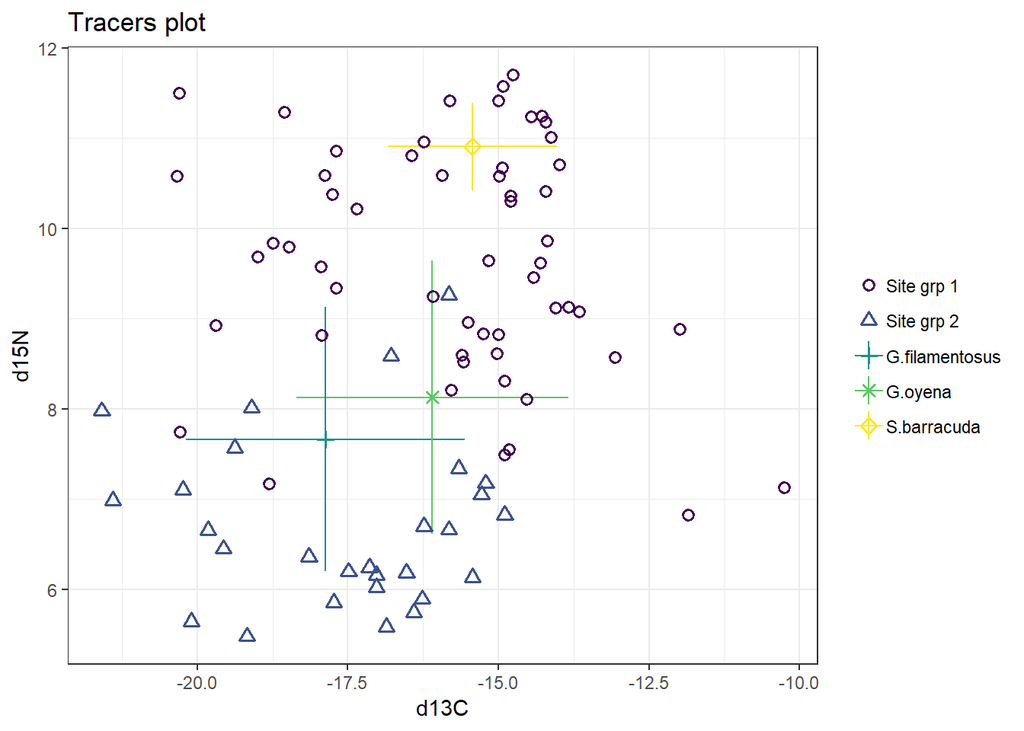

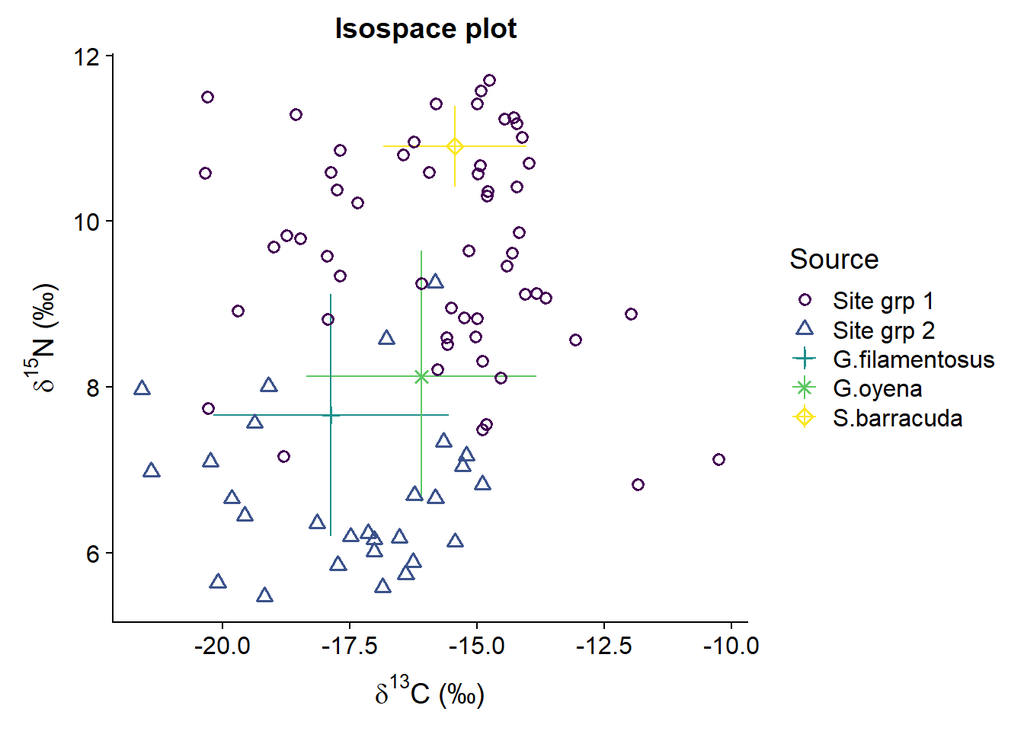

## Markov chain Monte Carlo (MCMC) model

```
##
## Running for group 1
##
##
##
##
## Running for group 2
##
##
```

### summary

#### model accuracy

```
## Gelman diagnostics - these values should all be close to 1.
## If not, try a longer run of simmr_mcmc.
##                Point est. Upper C.I.
## G.filamentosus          1       1.00
## G.oyena                 1       1.00
## S.barracuda             1       1.00
## sd_d13C                 1       1.01
## sd_d15N                 1       1.00
##                 2.5%   25%   50%   75% 97.5%
## G.filamentosus 0.024 0.083 0.137 0.204 0.324
## G.oyena        0.060 0.192 0.274 0.353 0.469
## S.barracuda    0.457 0.540 0.581 0.623 0.702
## sd_d13C        1.437 1.734 1.896 2.062 2.440
## sd_d15N        0.902 1.069 1.166 1.266 1.507
##                 mean    sd
## G.filamentosus 0.148 0.082
## G.oyena        0.271 0.110
## S.barracuda    0.581 0.063
## sd_d13C        1.904 0.253
## sd_d15N        1.174 0.151
##                G.filamentosus G.oyena S.barracuda sd_d13C sd_d15N
## G.filamentosus          1.000  -0.826       0.150   0.135   0.104
## G.oyena                -0.826   1.000      -0.681  -0.125  -0.204
## S.barracuda             0.150  -0.681       1.000   0.044   0.222
## sd_d13C                 0.135  -0.125       0.044   1.000   0.027
## sd_d15N                 0.104  -0.204       0.222   0.027   1.000
```

The model accuracy is validated with the Gelman diagonistics—these values should be close to 1

|  | Point est. | Upper C.I. |
| --- | --- | --- |
| G.filamentosus | 1.000 | 1.001 |
| G.oyena | 1.000 | 1.001 |
| S.barracuda | 1.001 | 1.004 |
| sd_d13C | 1.002 | 1.007 |
| sd_d15N | 1.003 | 1.005 |

#### statistics

Summary statistics

|  | mean | sd |
| --- | --- | --- |
| G.filamentosus | 0.148 | 0.082 |
| G.oyena | 0.271 | 0.110 |
| S.barracuda | 0.581 | 0.063 |
| sd_d13C | 1.904 | 0.253 |
| sd_d15N | 1.174 | 0.151 |

#### correlatiobs

Correlations

|  | G.filamentosus | G.oyena | S.barracuda | sd_d13C | sd_d15N |
| --- | --- | --- | --- | --- | --- |
| G.filamentosus | 1.000 | -0.826 | 0.150 | 0.135 | 0.104 |
| G.oyena | -0.826 | 1.000 | -0.681 | -0.125 | -0.204 |
| S.barracuda | 0.150 | -0.681 | 1.000 | 0.044 | 0.222 |
| sd_d13C | 0.135 | -0.125 | 0.044 | 1.000 | 0.027 |
| sd_d15N | 0.104 | -0.204 | 0.222 | 0.027 | 1.000 |

### Plotting model ouputs

#### boxplot

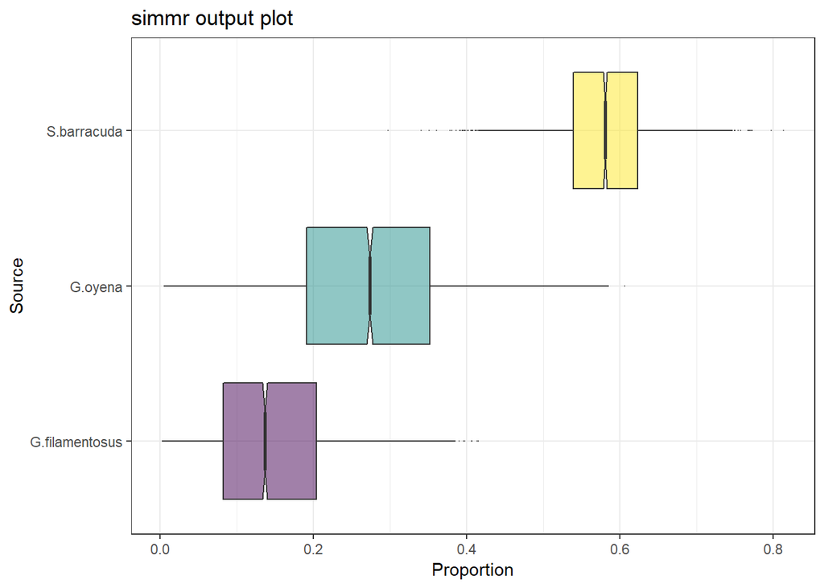

Proportion of isotopes at Kunduchi

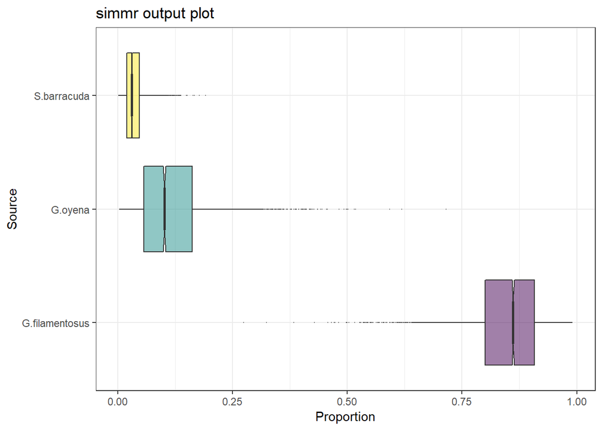

Proportion of isotopes at Mbegani

#### compare dietary proportion between sites,

```
## Prob ( proportion of G.filamentosus in group 1 > proportion of G.filamentosus in group 2 ) = 0
```

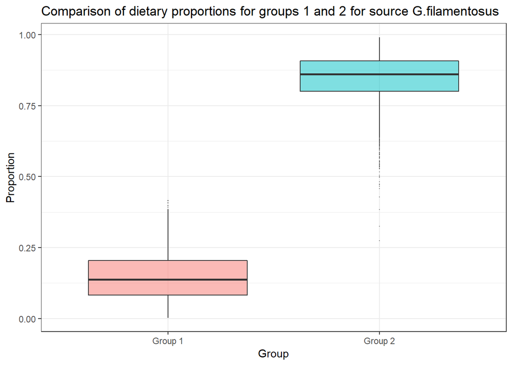

Dietary proportion of G.filamentosus between Kunduchi (Group1) and Mbegani (Group2)

```
## Prob ( proportion of G.oyena in group 1 > proportion of G.oyena in group 2 ) = 0.86
```

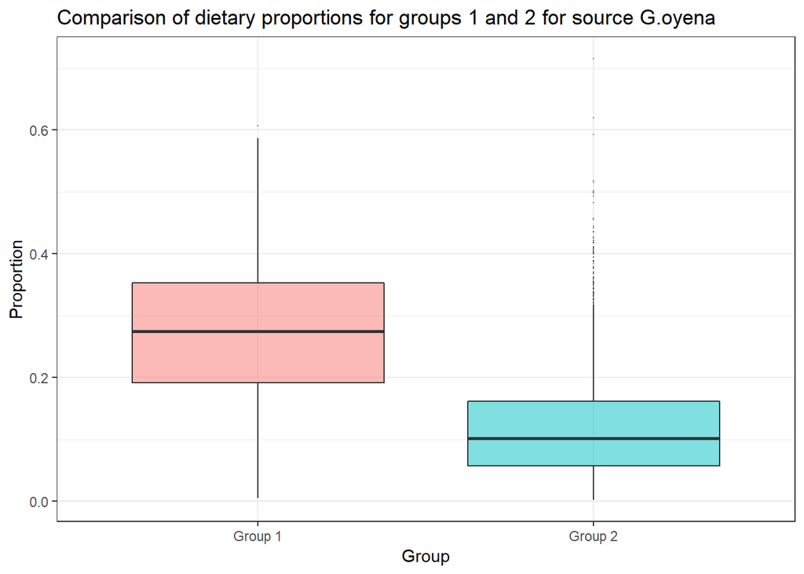

Dietary proportion of G.oyena between Kunduchi (Group1) and Mbegani (Group2)

```
## Prob ( proportion of S.barracuda in group 1 > proportion of S.barracuda in group 2 ) = 1
```

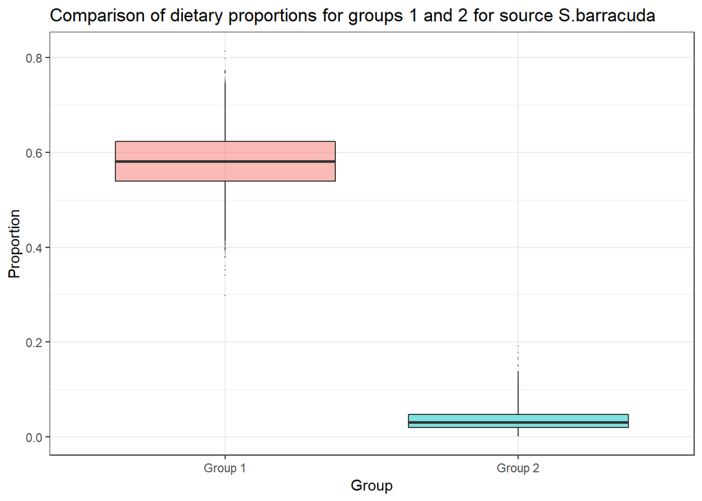

Dietary proportion of S.barracuda between Kunduchi (Group1) and Mbegani (Group2)

## Comparison between Muscle and Fin tissues

### plotting

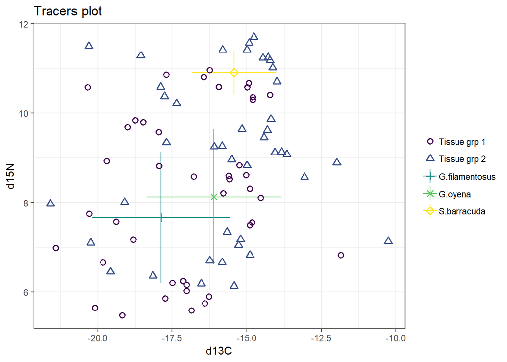

Isospace Plot between tissues

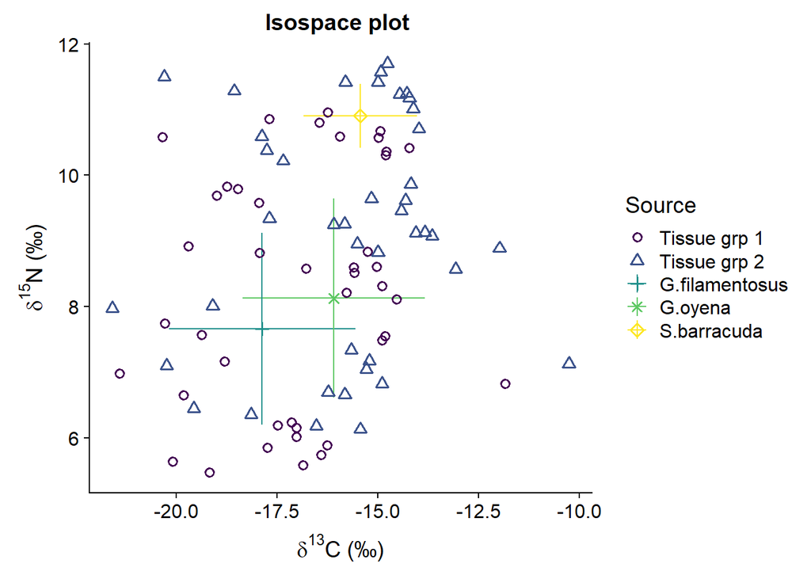

Isospace Plot between tissues

## Markov chain Monte Carlo (MCMC) model

```
##
## Running for group 1
##
##
##
##
## Running for group 2
##
##
```

### summary

#### model accuracy

```
## Gelman diagnostics - these values should all be close to 1.
## If not, try a longer run of simmr_mcmc.
##                Point est. Upper C.I.
## G.filamentosus          1       1.00
## G.oyena                 1       1.00
## S.barracuda             1       1.00
## sd_d13C                 1       1.01
## sd_d15N                 1       1.00
##                 2.5%   25%   50%   75% 97.5%
## G.filamentosus 0.124 0.412 0.544 0.654 0.805
## G.oyena        0.047 0.167 0.290 0.453 0.786
## S.barracuda    0.031 0.096 0.147 0.200 0.308
## sd_d13C        0.319 1.128 1.412 1.682 2.181
## sd_d15N        1.053 1.349 1.521 1.705 2.085
##                 mean    sd
## G.filamentosus 0.524 0.173
## G.oyena        0.324 0.198
## S.barracuda    0.152 0.073
## sd_d13C        1.384 0.449
## sd_d15N        1.533 0.270
##                G.filamentosus G.oyena S.barracuda sd_d13C sd_d15N
## G.filamentosus          1.000  -0.930       0.144  -0.197  -0.037
## G.oyena                -0.930   1.000      -0.498   0.078  -0.053
## S.barracuda             0.144  -0.498       1.000   0.254   0.232
## sd_d13C                -0.197   0.078       0.254   1.000   0.158
## sd_d15N                -0.037  -0.053       0.232   0.158   1.000
```

The model accuracy is validated with the Gelman diagonistics—these values should be close to 1

|  | Point est. | Upper C.I. |
| --- | --- | --- |
| G.filamentosus | 1.001 | 1.004 |
| G.oyena | 1.001 | 1.004 |
| S.barracuda | 1.000 | 1.002 |
| sd_d13C | 1.003 | 1.010 |
| sd_d15N | 1.000 | 1.001 |

#### statistics

Summary statistics

|  | mean | sd |
| --- | --- | --- |
| G.filamentosus | 0.524 | 0.173 |
| G.oyena | 0.324 | 0.198 |
| S.barracuda | 0.152 | 0.073 |
| sd_d13C | 1.384 | 0.449 |
| sd_d15N | 1.533 | 0.270 |

#### correlatiobs

Correlations

|  | G.filamentosus | G.oyena | S.barracuda | sd_d13C | sd_d15N |
| --- | --- | --- | --- | --- | --- |
| G.filamentosus | 1.000 | -0.930 | 0.144 | -0.197 | -0.037 |
| G.oyena | -0.930 | 1.000 | -0.498 | 0.078 | -0.053 |
| S.barracuda | 0.144 | -0.498 | 1.000 | 0.254 | 0.232 |
| sd_d13C | -0.197 | 0.078 | 0.254 | 1.000 | 0.158 |
| sd_d15N | -0.037 | -0.053 | 0.232 | 0.158 | 1.000 |

### Plotting model ouputs

#### boxplot

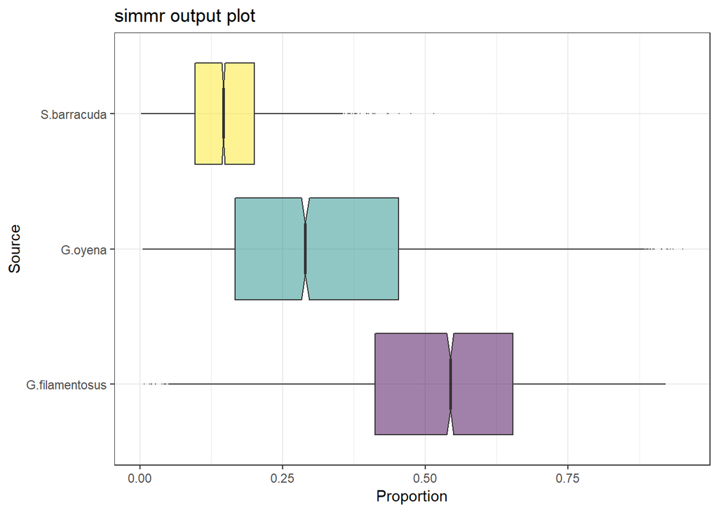

Proportion of isotopes in Fins

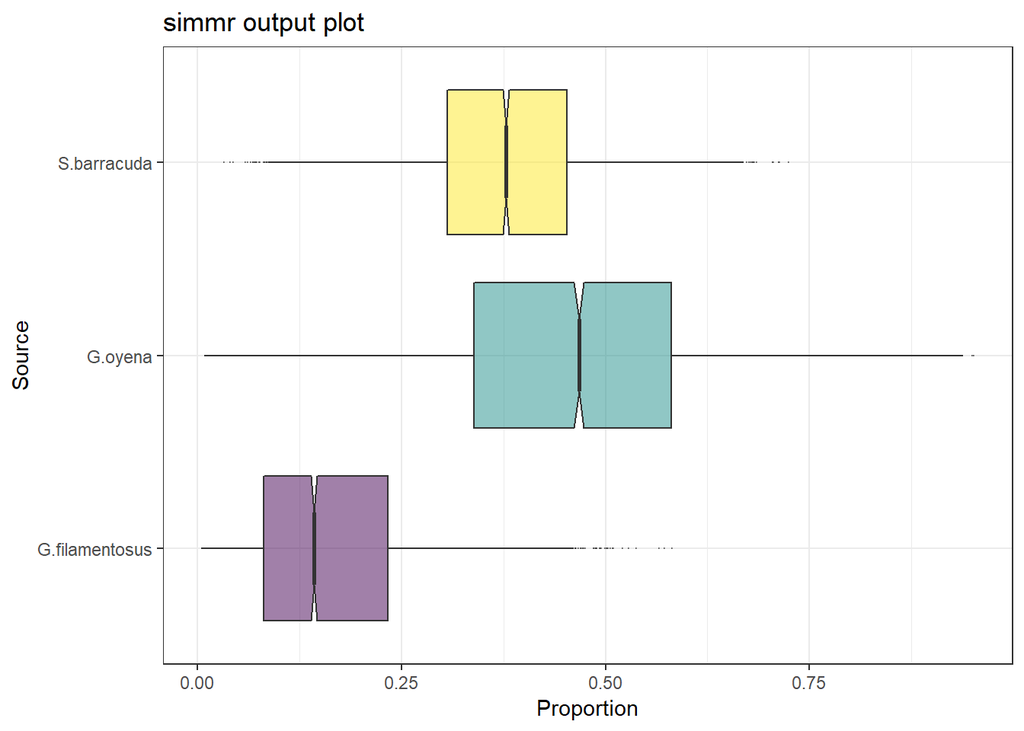

Proportion of isotopes in Muscle

```
## Prob ( proportion of G.filamentosus in group 1 > proportion of G.filamentosus in group 2 ) = 0.944
```

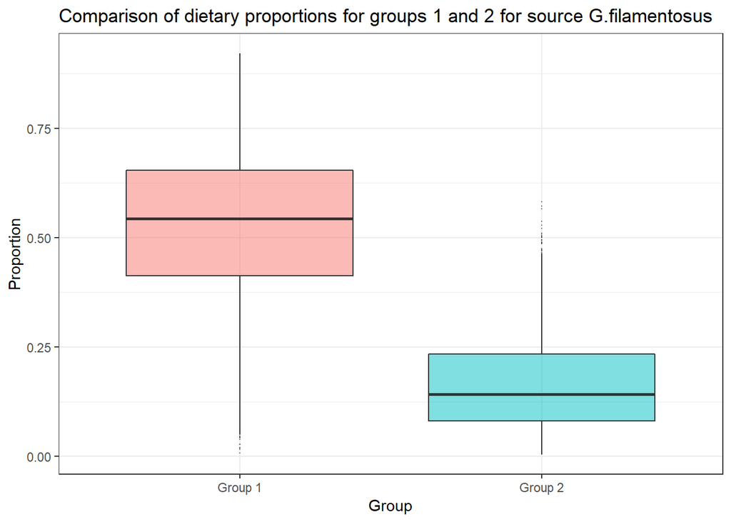

Dietary proportion of G.filamentosus between Fins (Group1) and Muscles (Group2)

```
## Prob ( proportion of G.oyena in group 1 > proportion of G.oyena in group 2 ) = 0.288
```

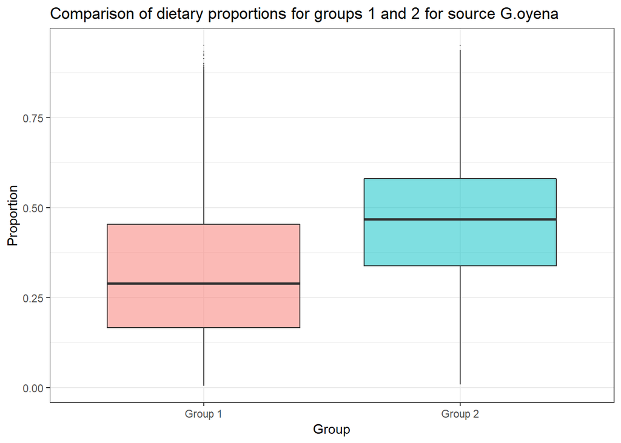

Dietary proportion of G.oyena between Fins (Group1) and Muscle (Group2)

```
## Prob ( proportion of S.barracuda in group 1 > proportion of S.barracuda in group 2 ) = 0.052
```

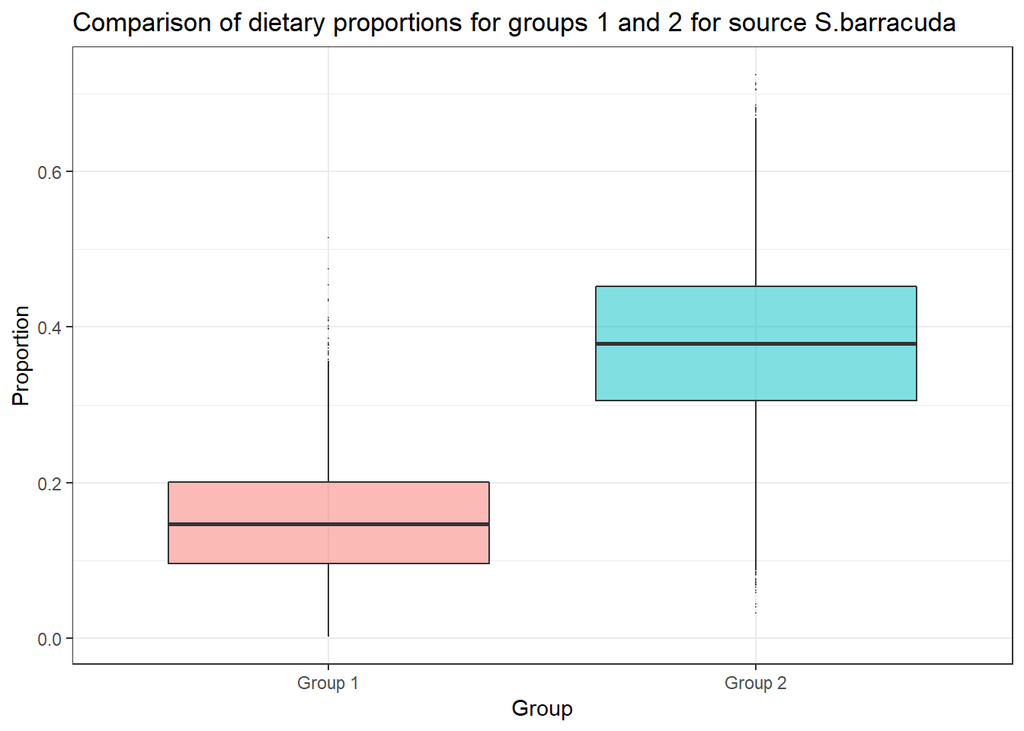

Dietary proportion of S.barracuda between Fins (Group1) and Muscles (Group2)

# References

Parnell, Andrew. 2016. *Simmr: A Stable Isotope Mixing Model*. https://CRAN.R-project.org/package=simmr.

R Core Team. 2018. *R: A Language and Environment for Statistical Computing*. Vienna, Austria: R Foundation for Statistical Computing. https://www.R-project.org/.

Wickham, Hadley, and Jennifer Bryan. 2018. *Readxl: Read Excel Files*. https://CRAN.R-project.org/package=readxl.

Wickham, Hadley, and Lionel Henry. 2018. *Tidyr: Easily Tidy Data with ’Spread()’ and ’Gather()’ Functions*. https://CRAN.R-project.org/package=tidyr.